# Sprawozdanie 2

Krzysztof Kotlarz

24.03.2020

# Lista 3

## Zadanie 5

### (i)

```
## Call:
## lda(owner ~ income + lotsize, data = dane)
##
## Prior probabilities of groups:
##   1   2
## 0.5 0.5
##
## Group means:
##     income   lotsize
## 1 26.49167 10.133333
## 2 19.13333  8.816667
##
## Coefficients of linear discriminants:
##                LD1
## income  -0.1453404
## lotsize -0.7590457
```

Średnie w poszczególnych grupach kształtują sie następująco:

- dla grupy *1* *income* = 26.49, *lotsize* = 10.13
- dla grupy *2* *income* = 19.13, *lotsize* = 8.82

### (ii)

Wartości współczynników klasyfikacyjnych są następujące:

- $LD1 = -0.1453 * income -0.759 * lotsize$

### (iV)

```r
LD1 <- predict(model.1)$x
sum(LD1 * (dane$owner == 1)) / sum(dane$owner == 1)
```

```
## [1] -1.034437
```

```r
sum(LD1 * (dane$owner == 2)) / sum(dane$owner == 2)
```

```
## [1] 1.034437
```

Średnie wartości funkcji dyskryminacyjnych dla:

- *owner = 1*: -1.034
- *owner = 2*: 1.034

### (v)

```r
owner.predict <- predict(model.1, dane[,1:2])
```

Za zbiór testowy przyjmujemy cały zbiór danych

### (vi)

```r
owner.predict$posterior[20,]
```

```
##          1          2
## 0.01612995 0.98387005
```

Prawdopodobieństwo przynależności obserwacji 20 dla poszczególnych grup:

- grupa *1*: 0.016
- grupa *2*: 0.984

### (vii)

Ta obserwacja zostanie zaklasyfikowana do grupy 2 z prawdopodobieństwem 98.4%

### (xiii)

```r
owner.classes <- owner.predict$class
sum(owner.classes==owner)/length(owner)
```

```
## [1] 0.875
```

Poprawana klasyfikacji 87.5% obserwacji

### (ix)

```
##         Predicted
## Original  1  2
##        1 11  1
##        2  2 10
```

Coefficient matrix przedstawia w wierszach przynależność obserwacji do klas ze zbioru, natomiast kolumny przynależność obserwacji do klas przewidziane przez model:

- 11 obserwacji bedących *owner* = 1, zostało poprawnie przewidziane przez model, natomiast 1 obserwacja błędnie
- 10 obserwacji bedących *owner* = 2, zostało poprawnie przewidziane przez model, natomiast 2 obserwacje błednie

## Zadnie 6.

# (i)

```
## Call:
## lda(t_uprawy ~ ., data = dane2)
##
## Prior probabilities of groups:
##         1         2         3
## 0.3314607 0.3988764 0.2696629
##
## Group means:
##         V2       V3       V4       V5       V6       V7        V8       V9
## 1 13.74475 2.010678 2.455593 17.03729 106.3390 2.840169 2.9823729 0.290000
## 2 12.27873 1.932676 2.244789 20.23803  94.5493 2.258873 2.0808451 0.363662
## 3 13.15375 3.333750 2.437083 21.41667  99.3125 1.678750 0.7814583 0.447500
##        V10      V11       V12      V13       V14
## 1 1.899322 5.528305 1.0620339 3.157797 1115.7119
## 2 1.630282 3.086620 1.0562817 2.785352  519.5070
## 3 1.153542 7.396250 0.6827083 1.683542  629.8958
##
## Coefficients of linear discriminants:
##              LD1           LD2
## V2  -0.403399781  0.8717930699
## V3   0.165254596  0.3053797325
## V4  -0.369075256  2.3458497486
## V5   0.154797889 -0.1463807654
## V6  -0.002163496 -0.0004627565
## V7   0.618052068 -0.0322128171
## V8  -1.661191235 -0.4919980543
## V9  -1.495818440 -1.6309537953
## V10  0.134092628 -0.3070875776
## V11  0.355055710  0.2532306865
## V12 -0.818036073 -1.5156344987
## V13 -1.157559376  0.0511839665
## V14 -0.002691206  0.0028529846
##
## Proportion of trace:
##    LD1    LD2
## 0.6875 0.3125
```

### (i)

Średnie w grupach prezentują się następująco:

```r
knitr::kable(model.2$means, caption = 'Średnie wartości w grupach', digits = 3, row.names = c(1,2,3,4))
```

Średnie wartości w grupach

|  | V2 | V3 | V4 | V5 | V6 | V7 | V8 | V9 | V10 | V11 | V12 | V13 | V14 |
| --- | --- | --- | --- | --- | --- | --- | --- | --- | --- | --- | --- | --- | --- |
| 1 | 13.745 | 2.011 | 2.456 | 17.037 | 106.339 | 2.840 | 2.982 | 0.290 | 1.899 | 5.528 | 1.062 | 3.158 | 1115.712 |
| 2 | 12.279 | 1.933 | 2.245 | 20.238 | 94.549 | 2.259 | 2.081 | 0.364 | 1.630 | 3.087 | 1.056 | 2.785 | 519.507 |
| 3 | 13.154 | 3.334 | 2.437 | 21.417 | 99.312 | 1.679 | 0.781 | 0.448 | 1.154 | 7.396 | 0.683 | 1.684 | 629.896 |

### (ii)

Współczynniki dla poszczególnych zmiennych są następujące:

```r
knitr::kable(model.2$scaling, digits = 3)
```

|  | LD1 | LD2 |
| --- | --- | --- |
| V2 | -0.403 | 0.872 |
| V3 | 0.165 | 0.305 |
| V4 | -0.369 | 2.346 |
| V5 | 0.155 | -0.146 |
| V6 | -0.002 | 0.000 |
| V7 | 0.618 | -0.032 |
| V8 | -1.661 | -0.492 |
| V9 | -1.496 | -1.631 |
| V10 | 0.134 | -0.307 |
| V11 | 0.355 | 0.253 |
| V12 | -0.818 | -1.516 |
| V13 | -1.158 | 0.051 |
| V14 | -0.003 | 0.003 |

### (iii)

Im większy współczynnik zmiennej tym jest on istotniejszy:

### (iv)

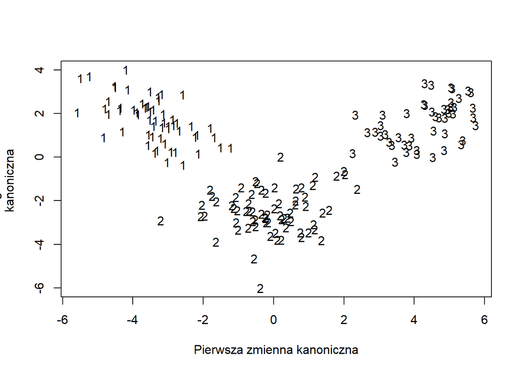

```r
sum(LD1 * (dane2$t_uprawy == 1)) / sum(dane2$t_uprawy == 1)
```

```
## [1] -3.422489
```

```r
sum(LD2 * (dane2$t_uprawy == 1)) / sum(dane2$t_uprawy == 1)
```

```
## [1] 1.691674
```

```r
sum(LD1 * (dane2$t_uprawy == 2)) / sum(dane2$t_uprawy == 2)
```

```
## [1] -0.07972623
```

```r
sum(LD2 * (dane2$t_uprawy == 2)) / sum(dane2$t_uprawy == 2)
```

```
## [1] -2.472656
```

```r
sum(LD1 * (dane2$t_uprawy == 3)) / sum(dane2$t_uprawy == 3)
```

```
## [1] 4.324737
```

```r
sum(LD2 * (dane2$t_uprawy == 3)) / sum(dane2$t_uprawy == 3)
```

```
## [1] 1.57812
```

Średnie wartości funkcji dyskryminacyjnych dla:

- **t_uprawy** = 1:
  - *LD1*: -3.422
  - *LD2*: 1.691
- **t_uprawy** = 2:
  - *LD1*: -0.079
  - *LD2*: -2.472
- **t_uprawy** = 3:
  - *LD1*: 4.324
  - *LD2*: 1.578

### (v)

```r
type_u.predict <- predict(model.2, dane2[,2:14])
```

Za zbiór testowy przyjmujemy cały zbiór danych

### (vi)

```r
type_u.predict$posterior[20,]
```

```
##            1            2            3
## 9.999994e-01 6.131886e-07 6.646280e-13
```

Prawdopodobieństwo przynależności obserwacji 20 dla poszczególnych grup:

- grupa 1: 0.99
- grupa 2: 6.13e-07
- grupa 3 : 6.64e-13

### (vii)

Obserwacja zostanie zaklasyfikowana do grupy 1 z prawdopdoobienstwem 99%

### (viii)

```r
type_u.classes <- type_u.predict$class
type_u.classperc <- sum(type_u.classes==dane2$t_uprawy)/length(dane2$t_uprawy)
type_u.classperc
```

```
## [1] 1
```

Poprawana klasyfikacji 100% obserwacji

### (ix)

```r
table(Original = dane2$t_uprawy, Predicted = predict(model.2)$class)
```

```
##         Predicted
## Original  1  2  3
##        1 59  0  0
##        2  0 71  0
##        3  0  0 48
```

Coefficient matrix przedstawia w wierszach przynależność obserwacji do klas ze zbioru, natomiast kolumny przynależność obserwacji do klas przewidziane przez model:

- Wszystkie obserwacje zostały poprawnie zaklasyfikowane do odpowiednich grup

# Lista 4

## Zadanie 7

```r
dane <- read.csv('http://theta.edu.pl/wp-content/uploads/2018/03/urine.csv', skip = 1, dec= '.', sep = ',', col.names = c('id','r','gravity','ph','osmo','cond','urea','calc'))
dane <- dane[,2:8]
```

```r
dane$r <- as.factor(dane$r)
dane <- na.omit(dane)
```

### (i)

```r
set.seed(123)

train_ind <- sample(seq_len(nrow(dane)), size = 50)

train <- dane[train_ind, ]
test <- dane[-train_ind, ]
```

### (ii)

```r
model.glm <- glm(r ~ . , data = train, family = binomial)
summary(model.glm)
```

```
##
## Call:
## glm(formula = r ~ ., family = binomial, data = train)
##
## Deviance Residuals:
##     Min       1Q   Median       3Q      Max
## -1.2673  -0.7415  -0.2858   0.3622   2.4701
##
## Coefficients:
##               Estimate Std. Error z value Pr(>|z|)
## (Intercept) -133.73202  237.76262  -0.562   0.5738
## gravity      135.94859  237.52922   0.572   0.5671
## ph            -0.58564    0.61048  -0.959   0.3374
## osmo           0.02444    0.01966   1.243   0.2139
## cond          -0.45606    0.26966  -1.691   0.0908 .
## urea          -0.03694    0.01843  -2.004   0.0450 *
## calc           0.71300    0.25894   2.754   0.0059 **
## ---
## Signif. codes:  0 '***' 0.001 '**' 0.01 '*' 0.05 '.' 0.1 ' ' 1
##
## (Dispersion parameter for binomial family taken to be 1)
##
##     Null deviance: 68.029  on 49  degrees of freedom
## Residual deviance: 40.756  on 43  degrees of freedom
## AIC: 54.756
##
## Number of Fisher Scoring iterations: 6
```

### (iii)

```r
model.glm.1 <- glm(r~. -gravity, data = train, family = binomial)
summary(model.glm.1)
```

```
##
## Call:
## glm(formula = r ~ . - gravity, family = binomial, data = train)
##
## Deviance Residuals:
##     Min       1Q   Median       3Q      Max
## -1.2367  -0.7331  -0.2814   0.3726   2.4754
##
## Coefficients:
##             Estimate Std. Error z value Pr(>|z|)
## (Intercept)  2.42196    3.89260   0.622  0.53381
## ph          -0.56723    0.58841  -0.964  0.33505
## osmo         0.03315    0.01389   2.387  0.01698 *
## cond        -0.55636    0.21721  -2.561  0.01043 *
## urea        -0.04175    0.01657  -2.520  0.01173 *
## calc         0.73879    0.25582   2.888  0.00388 **
## ---
## Signif. codes:  0 '***' 0.001 '**' 0.01 '*' 0.05 '.' 0.1 ' ' 1
##
## (Dispersion parameter for binomial family taken to be 1)
##
##     Null deviance: 68.029  on 49  degrees of freedom
## Residual deviance: 41.116  on 44  degrees of freedom
## AIC: 53.116
##
## Number of Fisher Scoring iterations: 6
```

Usunięto nieistotną zmienna **gravity**

```r
model.glm.2 <- glm(r~. -gravity -ph, data = train, family = binomial)
summary(model.glm.2)
```

```
##
## Call:
## glm(formula = r ~ . - gravity - ph, family = binomial, data = train)
##
## Deviance Residuals:
##     Min       1Q   Median       3Q      Max
## -1.3493  -0.6932  -0.3400   0.4255   2.2635
##
## Coefficients:
##             Estimate Std. Error z value Pr(>|z|)
## (Intercept) -1.17265    1.15309  -1.017  0.30917
## osmo         0.03183    0.01282   2.482  0.01307 *
## cond        -0.53501    0.20109  -2.661  0.00780 **
## urea        -0.03918    0.01513  -2.590  0.00961 **
## calc         0.70867    0.24575   2.884  0.00393 **
## ---
## Signif. codes:  0 '***' 0.001 '**' 0.01 '*' 0.05 '.' 0.1 ' ' 1
##
## (Dispersion parameter for binomial family taken to be 1)
##
##     Null deviance: 68.029  on 49  degrees of freedom
## Residual deviance: 42.076  on 45  degrees of freedom
## AIC: 52.076
##
## Number of Fisher Scoring iterations: 6
```

Usunięto nieistotną zmienna **ph**

### (iV)

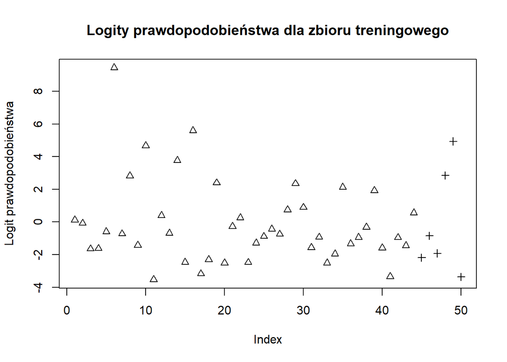

```r
predictGLM <- predict(model.glm.2, newdata = train)
plot(predictGLM, pch = as.numeric(dane$r) + 1, ylab = 'Logit prawdopodobieństwa', main = 'Logity prawdopodobieństwa dla zbioru treningowego')
```

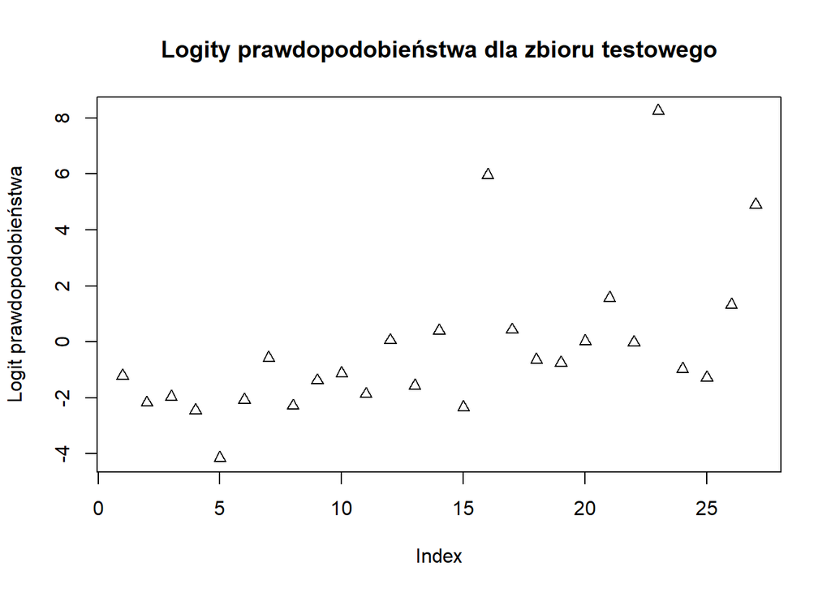

```r
predictLR <- predict(model.glm.2, newdata = test)
plot(predictLR, pch = as.numeric(dane$r) + 1, ylab = 'Logit prawdopodobieństwa', main = 'Logity prawdopodobieństwa dla zbioru testowego')
```

```r
TAB <- table(test[,1], predictLR > 0)
knitr::kable(TAB)
```

|  | FALSE | TRUE |
| --- | --- | --- |
| 0 | 13 | 2 |
| 1 | 5 | 7 |

```r
mcrlr <- 1-sum(diag(TAB))/sum(TAB)
mcrlr
```

```
## [1] 0.2592593
```

Błąd klasyfikacji wynosi 25.9%

### (v)

```r
model.lda <- lda(r~. -gravity -ph, data = train)
model.lda
```

```
## Call:
## lda(r ~ . - gravity - ph, data = train)
##
## Prior probabilities of groups:
##    0    1
## 0.58 0.42
##
## Group means:
##       osmo     cond     urea     calc
## 0 568.8966 20.85862 236.7586 2.862414
## 1 637.2381 21.07143 264.2857 6.002857
##
## Coefficients of linear discriminants:
##              LD1
## osmo  0.01625975
## cond -0.27558553
## urea -0.01979592
## calc  0.33438051
```

```r
lda.predict <- predict(model.lda, test[ ,2:7])
pid.classperc <- sum(lda.predict$class == test[ ,1]) / nrow(test)
pid.classperc
```

```
## [1] 0.7407407
```

```r
1 - pid.classperc
```

```
## [1] 0.2592593
```

Bład klasyfikacji w przypadku regresji logistycznej jak i metody LDA jest taki sam.

## Zadanie 8

```r
dane3 <- read.table('http://theta.edu.pl/wp-content/uploads/2018/03/puls2.csv', header = TRUE, sep = ';')

attach(dane3)

dane3$Palacz <- as.factor(dane3$Palacz)
```

### (i)

```r
set.seed(333)

smp_size <- floor(0.75 * nrow(dane3))

train_ind <- sample(seq_len(nrow(dane3)), size = smp_size)

train <- dane3[train_ind, ]
test <- dane3[-train_ind, ]
```

### (ii)

```r
model.4 <- glm(TetnoSpocz~Palacz+Waga, data = train, family = binomial)
summary(model.4)
```

```
##
## Call:
## glm(formula = TetnoSpocz ~ Palacz + Waga, family = binomial,
##     data = train)
##
## Deviance Residuals:
##     Min       1Q   Median       3Q      Max
## -1.0962  -0.8943  -0.4975   0.8938   2.7195
##
## Coefficients:
##             Estimate Std. Error z value Pr(>|z|)
## (Intercept) -7.62354    2.25967  -3.374 0.000742 ***
## Palacz1     -0.06030    0.62090  -0.097 0.922637
## Waga         0.08231    0.02564   3.210 0.001325 **
## ---
## Signif. codes:  0 '***' 0.001 '**' 0.01 '*' 0.05 '.' 0.1 ' ' 1
##
## (Dispersion parameter for binomial family taken to be 1)
##
##     Null deviance: 90.354  on 68  degrees of freedom
## Residual deviance: 74.768  on 66  degrees of freedom
## AIC: 80.768
##
## Number of Fisher Scoring iterations: 4
```

### (iii)

```r
model.5 <- glm(TetnoSpocz~Waga, data = train, family = binomial)
summary(model.5)
```

```
##
## Call:
## glm(formula = TetnoSpocz ~ Waga, family = binomial, data = train)
##
## Deviance Residuals:
##     Min       1Q   Median       3Q      Max
## -1.1138  -0.8880  -0.4937   0.8784   2.7250
##
## Coefficients:
##             Estimate Std. Error z value Pr(>|z|)
## (Intercept) -7.63616    2.25074  -3.393 0.000692 ***
## Waga         0.08225    0.02556   3.218 0.001292 **
## ---
## Signif. codes:  0 '***' 0.001 '**' 0.01 '*' 0.05 '.' 0.1 ' ' 1
##
## (Dispersion parameter for binomial family taken to be 1)
##
##     Null deviance: 90.354  on 68  degrees of freedom
## Residual deviance: 74.778  on 67  degrees of freedom
## AIC: 78.778
##
## Number of Fisher Scoring iterations: 4
```

Usunięto nieistotną zmienna *Palacz*. Ostatecznie w modelu pozostaje zmienna *Waga*

### (iv)

```r
model.m1 <- glm(TetnoSpocz~Palacz*Waga, data = train, family = binomial)
summary(model.m1)
```

```
##
## Call:
## glm(formula = TetnoSpocz ~ Palacz * Waga, family = binomial,
##     data = train)
##
## Deviance Residuals:
##     Min       1Q   Median       3Q      Max
## -1.1661  -0.9259  -0.4735   0.8040   2.3105
##
## Coefficients:
##               Estimate Std. Error z value Pr(>|z|)
## (Intercept)   -5.22692    2.24231  -2.331   0.0198 *
## Palacz1      -22.16414   15.06934  -1.471   0.1413
## Waga           0.05478    0.02554   2.145   0.0319 *
## Palacz1:Waga   0.24592    0.16535   1.487   0.1369
## ---
## Signif. codes:  0 '***' 0.001 '**' 0.01 '*' 0.05 '.' 0.1 ' ' 1
##
## (Dispersion parameter for binomial family taken to be 1)
##
##     Null deviance: 90.354  on 68  degrees of freedom
## Residual deviance: 69.252  on 65  degrees of freedom
## AIC: 77.252
##
## Number of Fisher Scoring iterations: 7
```

Nieistotna zmienna *Palacz* oraz interakcja pomiedzy zmiennymi *Palacz* i *Waga*

### (v)

```r
model.m2 <- glm(TetnoSpocz~Waga + Palacz:Waga, data = train, family = binomial)
summary(model.m2)
```

```
##
## Call:
## glm(formula = TetnoSpocz ~ Waga + Palacz:Waga, family = binomial,
##     data = train)
##
## Deviance Residuals:
##     Min       1Q   Median       3Q      Max
## -1.1416  -0.8788  -0.5058   0.8901   2.7291
##
## Coefficients:
##               Estimate Std. Error z value Pr(>|z|)
## (Intercept)  -7.629116   2.242677  -3.402 0.000669 ***
## Waga          0.081867   0.025582   3.200 0.001373 **
## Waga:Palacz1  0.001037   0.007014   0.148 0.882470
## ---
## Signif. codes:  0 '***' 0.001 '**' 0.01 '*' 0.05 '.' 0.1 ' ' 1
##
## (Dispersion parameter for binomial family taken to be 1)
##
##     Null deviance: 90.354  on 68  degrees of freedom
## Residual deviance: 74.756  on 66  degrees of freedom
## AIC: 80.756
##
## Number of Fisher Scoring iterations: 4
```

```r
model.m3 <- glm(TetnoSpocz~ Palacz + Palacz:Waga, data = train, family = binomial)
summary(model.m3)
```

```
##
## Call:
## glm(formula = TetnoSpocz ~ Palacz + Palacz:Waga, family = binomial,
##     data = train)
##
## Deviance Residuals:
##     Min       1Q   Median       3Q      Max
## -1.1661  -0.9259  -0.4735   0.8040   2.3105
##
## Coefficients:
##               Estimate Std. Error z value Pr(>|z|)
## (Intercept)   -5.22692    2.24231  -2.331   0.0198 *
## Palacz1      -22.16414   15.06934  -1.471   0.1413
## Palacz0:Waga   0.05478    0.02554   2.145   0.0319 *
## Palacz1:Waga   0.30071    0.16337   1.841   0.0657 .
## ---
## Signif. codes:  0 '***' 0.001 '**' 0.01 '*' 0.05 '.' 0.1 ' ' 1
##
## (Dispersion parameter for binomial family taken to be 1)
##
##     Null deviance: 90.354  on 68  degrees of freedom
## Residual deviance: 69.252  on 65  degrees of freedom
## AIC: 77.252
##
## Number of Fisher Scoring iterations: 7
```

```r
model.m4 <- glm(TetnoSpocz~Palacz:Waga, data = train, family = binomial)
summary(model.m4)
```

```
##
## Call:
## glm(formula = TetnoSpocz ~ Palacz:Waga, family = binomial, data = train)
##
## Deviance Residuals:
##     Min       1Q   Median       3Q      Max
## -1.1416  -0.8788  -0.5058   0.8901   2.7291
##
## Coefficients:
##              Estimate Std. Error z value Pr(>|z|)
## (Intercept)  -7.62912    2.24268  -3.402 0.000669 ***
## Palacz0:Waga  0.08187    0.02558   3.200 0.001373 **
## Palacz1:Waga  0.08290    0.02588   3.204 0.001358 **
## ---
## Signif. codes:  0 '***' 0.001 '**' 0.01 '*' 0.05 '.' 0.1 ' ' 1
##
## (Dispersion parameter for binomial family taken to be 1)
##
##     Null deviance: 90.354  on 68  degrees of freedom
## Residual deviance: 74.756  on 66  degrees of freedom
## AIC: 80.756
##
## Number of Fisher Scoring iterations: 4
```

Model **M4** zawiera zmienne istotne: jest to model uwzględniający tylko interakcje pomiedzy zmiennymi *Palacz* i *Waga*

#### Dla pełnego modelu

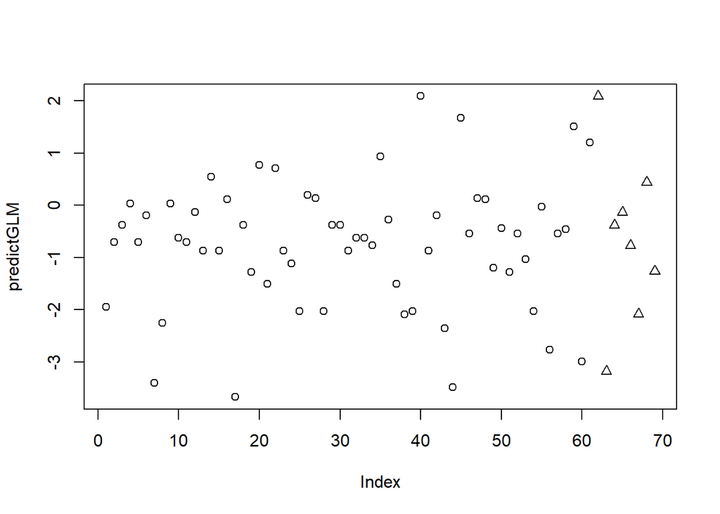

```r
predictGLM <- predict(model.4, newdata = train)
plot(predictGLM, pch = as.numeric(dane3$TetnoSpocz))
```

```r
predictLR <- predict(model.4, newdata = test)
TAB <- table(test[,1], predictLR > 0)
knitr::kable(TAB)
```

|  | FALSE | TRUE |
| --- | --- | --- |
| Niskie | 17 | 0 |
| Wysokie | 4 | 2 |

```r
mcrlr <- 1-sum(diag(TAB))/sum(TAB)
mcrlr
```

```
## [1] 0.173913
```

#### Dla M4

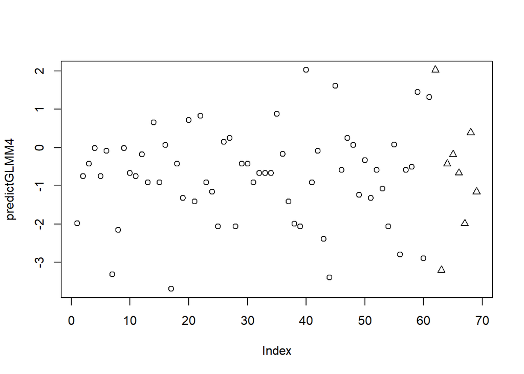

```r
predictGLMM4 <- predict(model.m4, newdata = train)
plot(predictGLMM4, pch = as.numeric(dane3$TetnoSpocz))
```

```r
predictLRM4 <- predict(model.m4, newdata = test)
TABM4 <- table(test[,1], predictLRM4 > 0)
knitr::kable(TABM4)
```

|  | FALSE | TRUE |
| --- | --- | --- |
| Niskie | 17 | 0 |
| Wysokie | 4 | 2 |

```r
mcrlr <- 1-sum(diag(TABM4))/sum(TABM4)
mcrlr
```

```
## [1] 0.173913
```

```r
library(MASS)
model.lda <- lda(TetnoSpocz~Palacz + Waga, data = train)
model.lda
```

```
## Call:
## lda(TetnoSpocz ~ Palacz + Waga, data = train)
##
## Prior probabilities of groups:
##    Niskie   Wysokie
## 0.6376812 0.3623188
##
## Group means:
##           Palacz1     Waga
## Niskie  0.3181818 78.81818
## Wysokie 0.2800000 92.68000
##
## Coefficients of linear discriminants:
##                LD1
## Palacz1 0.03296072
## Waga    0.07304346
```

```r
lda.predict <- predict(model.lda, test[ ,2:3])
pid.classperc <- sum(lda.predict$class == test[ ,1]) / nrow(test)
pid.classperc
```

```
## [1] 0.826087
```

```r
1 - pid.classperc
```

```
## [1] 0.173913
```